# R Notebook: AIAG Attribute MSA/GRR Example

Cliff Long

# LOAD PACKAGES

```r
library(pander)
```

[output not shown]

# CITATION

Citation for R to include in report:

```r
x_cite <- citation()
print(x_cite, style = "text")
```

```
R Core Team (2026). _R: A Language and Environment for Statistical Computing_. R Foundation
for Statistical Computing, Vienna, Austria. doi:10.32614/R.manuals
<https://doi.org/10.32614/R.manuals>. <https://www.R-project.org/>.
```

Session info:

```r
s_info <- sessionInfo()

cat(s_info$R.version$version.string)
```

R version 4.6.0 (2026-04-24 ucrt)

```r
cat("\n \n Base Packages \n")
```

Base Packages

```r
cat(s_info$basePkgs)
```

stats graphics grDevices utils datasets methods base

```r
cat("\n \n Other Packages \n")
```

Other Packages

```r
cat(names(s_info$otherPkgs))
```

pander InformationValue ISLR caret lattice sessioninfo stringr broom purrr scales ggplot2 irr lpSolve writexl tidyr dplyr janitor readxl here

# REFERENCES

- AIAG. AIAG Measurement Systems Analysis (MSA) Reference Manual. 4th ed., Chrysler, Ford, GM, 2010.
- Confusion Matrix. https://en.wikipedia.org/wiki/Confusion_matrix.
- “Fleiss’ Kappa.” Wikipedia, 25 Jan. 2024. Wikipedia, https://en.wikipedia.org/w/index.php?title=Fleiss%27_kappa&oldid=1198843670.
- Fleiss’ Kappa - Citizendium. https://en.citizendium.org/wiki/Fleiss%27_kappa. Accessed 29 Mar. 2024.

# LOAD DATA

```r
# initial load
fname <- "aiag_table_12_attr_msa.xlsx"
fsheet <- "aiag_table_12_attr_msa_long"
```

```r
# get data
d0 <- read_excel(path = here::here('data', fname), sheet = fsheet)
#glimpse(d0)
```

```r
# clean data variable names
d1 <- d0 %>% clean_names()
glimpse(d1)
```

```
Rows: 450
Columns: 8
$ part       <dbl> 1, 2, 3, 4, 5, 6, 7, 8, 9, 10, 11, 12, 13, 14, 15, 16, 17, 18, 19, 20, 21, 22, 23, …
$ appr_trial <chr> "A-1", "A-1", "A-1", "A-1", "A-1", "A-1", "A-1", "A-1", "A-1", "A-1", "A-1", "A-1",…
$ rating     <dbl> 1, 1, 0, 0, 0, 1, 1, 1, 0, 1, 1, 0, 1, 1, 1, 1, 1, 1, 1, 1, 1, 0, 1, 1, 0, 0, 1, 1,…
$ reference  <dbl> 1, 1, 0, 0, 0, 1, 1, 1, 0, 1, 1, 0, 1, 1, 1, 1, 1, 1, 1, 1, 1, 0, 1, 1, 0, 0, 1, 1,…
$ ref_value  <dbl> 0.476901, 0.590150, 0.576459, 0.566152, 0.570360, 0.544951, 0.465454, 0.502295, 0.4…
$ partnum    <chr> "p_01", "p_02", "p_03", "p_04", "p_05", "p_06", "p_07", "p_08", "p_09", "p_10", "p_…
$ appr       <chr> "A", "A", "A", "A", "A", "A", "A", "A", "A", "A", "A", "A", "A", "A", "A", "A", "A"…
$ trial      <chr> "T1", "T1", "T1", "T1", "T1", "T1", "T1", "T1", "T1", "T1", "T1", "T1", "T1", "T1",…
```

# PREP DATA

The following assumes that the spreadsheet data is in LONG format (vs WIDE).

```r
### rename vars
# inspector (from appraiser)
# specimen (from part)
# true_state (from reference)
# trial
# one (add)
# trial_label (unused in this example, no blinding btwn trials)
# trial_result (from xxxxx)

d1a <- d1 %>%
  rename(inspector = appr,
         specimen = partnum,
         true_state = reference,
         trial = trial,
         trial_result = rating) %>%
  mutate(one = 1) %>%
  select(-one_of('part'))

glimpse(d1a)
```

```
Rows: 450
Columns: 8
$ appr_trial   <chr> "A-1", "A-1", "A-1", "A-1", "A-1", "A-1", "A-1", "A-1", "A-1", "A-1", "A-1", "A-1…
$ trial_result <dbl> 1, 1, 0, 0, 0, 1, 1, 1, 0, 1, 1, 0, 1, 1, 1, 1, 1, 1, 1, 1, 1, 0, 1, 1, 0, 0, 1, …
$ true_state   <dbl> 1, 1, 0, 0, 0, 1, 1, 1, 0, 1, 1, 0, 1, 1, 1, 1, 1, 1, 1, 1, 1, 0, 1, 1, 0, 0, 1, …
$ ref_value    <dbl> 0.476901, 0.590150, 0.576459, 0.566152, 0.570360, 0.544951, 0.465454, 0.502295, 0…
$ specimen     <chr> "p_01", "p_02", "p_03", "p_04", "p_05", "p_06", "p_07", "p_08", "p_09", "p_10", "…
$ inspector    <chr> "A", "A", "A", "A", "A", "A", "A", "A", "A", "A", "A", "A", "A", "A", "A", "A", "…
$ trial        <chr> "T1", "T1", "T1", "T1", "T1", "T1", "T1", "T1", "T1", "T1", "T1", "T1", "T1", "T1…
$ one          <dbl> 1, 1, 1, 1, 1, 1, 1, 1, 1, 1, 1, 1, 1, 1, 1, 1, 1, 1, 1, 1, 1, 1, 1, 1, 1, 1, 1, …
```

```r
head(d1a)
```

| appr_trial | trial_result | true_state | ref_value | specimen | inspector | trial | one |
| --- | --- | --- | --- | --- | --- | --- | --- |
| A-1 | 1 | 1 | 0.476901 | p_01 | A | T1 | 1 |
| A-1 | 1 | 1 | 0.590150 | p_02 | A | T1 | 1 |
| A-1 | 0 | 0 | 0.576459 | p_03 | A | T1 | 1 |
| A-1 | 0 | 0 | 0.566152 | p_04 | A | T1 | 1 |
| A-1 | 0 | 0 | 0.570360 | p_05 | A | T1 | 1 |
| A-1 | 1 | 1 | 0.544951 | p_06 | A | T1 | 1 |

```r
# quick look
with(d1a, table(trial, trial_result))
```

```
     trial_result
trial   0   1
   T1  48 102
   T2  49 101
   T3  51  99
```

Create variable to indicate if appraiser result matches the True State.

```r
# pivot structure

# create variable to indicate if appraiser result matches true state
d2 <- d1a %>%
  mutate(trial_true_agree = if_else(trial_result == true_state, 1, 0))

glimpse(d2)
```

```
Rows: 450
Columns: 9
$ appr_trial       <chr> "A-1", "A-1", "A-1", "A-1", "A-1", "A-1", "A-1", "A-1", "A-1", "A-1", "A-1", …
$ trial_result     <dbl> 1, 1, 0, 0, 0, 1, 1, 1, 0, 1, 1, 0, 1, 1, 1, 1, 1, 1, 1, 1, 1, 0, 1, 1, 0, 0,…
$ true_state       <dbl> 1, 1, 0, 0, 0, 1, 1, 1, 0, 1, 1, 0, 1, 1, 1, 1, 1, 1, 1, 1, 1, 0, 1, 1, 0, 0,…
$ ref_value        <dbl> 0.476901, 0.590150, 0.576459, 0.566152, 0.570360, 0.544951, 0.465454, 0.50229…
$ specimen         <chr> "p_01", "p_02", "p_03", "p_04", "p_05", "p_06", "p_07", "p_08", "p_09", "p_10…
$ inspector        <chr> "A", "A", "A", "A", "A", "A", "A", "A", "A", "A", "A", "A", "A", "A", "A", "A…
$ trial            <chr> "T1", "T1", "T1", "T1", "T1", "T1", "T1", "T1", "T1", "T1", "T1", "T1", "T1",…
$ one              <dbl> 1, 1, 1, 1, 1, 1, 1, 1, 1, 1, 1, 1, 1, 1, 1, 1, 1, 1, 1, 1, 1, 1, 1, 1, 1, 1,…
$ trial_true_agree <dbl> 1, 1, 1, 1, 1, 1, 1, 1, 1, 1, 1, 1, 1, 1, 1, 1, 1, 1, 1, 1, 1, 1, 1, 1, 1, 1,…
```

```r
# OPTIONAL
# export to excel to include in report
# write_xlsx(x = d2, path = "d2_out_4report.xlsx")
```

Quick verification by count.

```r
# quick verification
xtabs(~ inspector + specimen, data = d2)
```

```
         specimen
inspector p_01 p_02 p_03 p_04 p_05 p_06 p_07 p_08 p_09 p_10 p_11 p_12 p_13 p_14 p_15 p_16 p_17 p_18
        A    3    3    3    3    3    3    3    3    3    3    3    3    3    3    3    3    3    3
        B    3    3    3    3    3    3    3    3    3    3    3    3    3    3    3    3    3    3
        C    3    3    3    3    3    3    3    3    3    3    3    3    3    3    3    3    3    3
         specimen
inspector p_19 p_20 p_21 p_22 p_23 p_24 p_25 p_26 p_27 p_28 p_29 p_30 p_31 p_32 p_33 p_34 p_35 p_36
        A    3    3    3    3    3    3    3    3    3    3    3    3    3    3    3    3    3    3
        B    3    3    3    3    3    3    3    3    3    3    3    3    3    3    3    3    3    3
        C    3    3    3    3    3    3    3    3    3    3    3    3    3    3    3    3    3    3
         specimen
inspector p_37 p_38 p_39 p_40 p_41 p_42 p_43 p_44 p_45 p_46 p_47 p_48 p_49 p_50
        A    3    3    3    3    3    3    3    3    3    3    3    3    3    3
        B    3    3    3    3    3    3    3    3    3    3    3    3    3    3
        C    3    3    3    3    3    3    3    3    3    3    3    3    3    3
```

# ANALYSIS - Kappa Method

```r
# prep data format for irr package

keep_wide <- c('trial', 'specimen', 'inspector', 'trial_result')
drop_cols <- c('trial', 'specimen')

d2w <- d2 %>%
  select(all_of(keep_wide)) %>%
  pivot_wider(names_from = 'inspector',
              values_from = 'trial_result') %>%
  select(-one_of(drop_cols))
```

```r
glimpse(d2w)
```

```
Rows: 150
Columns: 3
$ A <dbl> 1, 1, 0, 0, 0, 1, 1, 1, 0, 1, 1, 0, 1, 1, 1, 1, 1, 1, 1, 1, 1, 0, 1, 1, 0, 0, 1, 1, 1, 0, 1,…
$ B <dbl> 1, 1, 0, 0, 0, 1, 1, 1, 0, 1, 1, 0, 1, 1, 1, 1, 1, 1, 1, 1, 1, 0, 1, 1, 0, 0, 1, 1, 1, 0, 1,…
$ C <dbl> 1, 1, 0, 0, 0, 1, 1, 1, 0, 1, 1, 0, 1, 1, 1, 1, 1, 1, 1, 1, 0, 1, 1, 1, 0, 0, 1, 1, 1, 0, 1,…
```

```r
head(d2w)
```

| A | B | C |
| --- | --- | --- |
| 1 | 1 | 1 |
| 1 | 1 | 1 |
| 0 | 0 | 0 |
| 0 | 0 | 0 |
| 0 | 0 | 0 |
| 1 | 1 | 1 |

### compare raters A and B

```r
d_ratings_AB <- d2w %>% select(all_of(c('A', 'B')))
(kappa2_AB <- kappa2(ratings = d_ratings_AB))
```

```
 Cohen's Kappa for 2 Raters (Weights: unweighted)

 Subjects = 150
   Raters = 2
    Kappa = 0.863

        z = 10.6
  p-value = 0
```

### compare raters A and C

```r
d_ratings_AC <- d2w %>% select(all_of(c('A', 'C')))
(kappa2_AC <- kappa2(ratings = d_ratings_AC))
```

```
 Cohen's Kappa for 2 Raters (Weights: unweighted)

 Subjects = 150
   Raters = 2
    Kappa = 0.776

        z = 9.51
  p-value = 0
```

### compare raters B and C

```r
d_ratings_BC <- d2w %>% select(all_of(c('B', 'C')))
(kappa2_BC <- kappa2(ratings = d_ratings_BC))
```

```
 Cohen's Kappa for 2 Raters (Weights: unweighted)

 Subjects = 150
   Raters = 2
    Kappa = 0.788

        z = 9.67
  p-value = 0
```

NOTE: matches the AIAG output page 129

## IRR: overall analysis Fleiss Kappa

Fleiss Kappa

```r
kappam.fleiss(d2w)
```

```
 Fleiss' Kappa for m Raters

 Subjects = 150
   Raters = 3
    Kappa = 0.809

        z = 17.2
  p-value = 0
```

Fleiss Kappa with detail

```r
kappam.fleiss(d2w, detail = TRUE)
```

```
 Fleiss' Kappa for m Raters

 Subjects = 150
   Raters = 3
    Kappa = 0.809

        z = 17.2
  p-value = 0

   Kappa      z p.value
0  0.809 17.155   0.000
1  0.809 17.155   0.000
```

## IRR: overall analysis Lights Kappa

```r
kappam.light(d2w)
```

[output not shown]

# IRR: percent agreement among raters

Using the “irr” package and the “agree” function.

```r
irr::agree(d2w)
```

```
 Percentage agreement (Tolerance=0)

 Subjects = 150
   Raters = 3
  %-agree = 87.3
```

# ANALYSIS - agreement with standard

## agreement with standard - INTER-rater

```r
d2 %>%
  # add confidence intervals
  count(trial_true_agree) %>%
  mutate(prop = n / sum(n),
         lower = lapply(n, prop.test, n = sum(n)),
         upper = sapply(lower, function(x) x$conf.int[2]),
         lower = sapply(lower, function(x) x$conf.int[1])) %>%
  filter(trial_true_agree == 1) %>%
  pander()
```

```
---------------------------------------------------
 trial_true_agree    n     prop    lower    upper
------------------ ----- -------- -------- --------
        1           422   0.9378   0.9103   0.9575
---------------------------------------------------
```

# EXPLORATORY-ONLY TABLES AND PLOTS

## agreement with standard - by inspector

```r
### prep data for plotting
d2_summary_byinsp <- d2 %>%
  group_by(inspector) %>%
  summarize(ct_agree = sum(trial_true_agree),
            total_obs = length(trial_true_agree),
            true_state = true_state[1]) %>%
  mutate(prop_correct = map2(ct_agree, total_obs, ~ prop.test(.x, .y, conf.level = 0.95) %>%
                               broom::tidy())) %>%
  unnest(prop_correct) %>%
  mutate(cross50 = case_when(conf.low <= 0.5 ~ 'below',
                             TRUE ~ 'above'))

pander(d2_summary_byinsp)
```

```
----------------------------------------------------------------------
 inspector   ct_agree   total_obs   true_state   estimate   statistic
----------- ---------- ----------- ------------ ---------- -----------
     A         142         150          1         0.9467      117.9

     B         145         150          1         0.9667      128.8

     C         135         150          1          0.9        94.41
----------------------------------------------------------------------

Table: Table continues below


-------------------------------------------------------------------------------
  p.value    parameter   conf.low   conf.high               method
----------- ----------- ---------- ----------- --------------------------------
 1.799e-27       1        0.8941      0.975     1-sample proportions test with
                                                    continuity correction

 7.476e-30       1        0.9199     0.9877     1-sample proportions test with
                                                    continuity correction

 2.569e-22       1        0.8377      0.941     1-sample proportions test with
                                                    continuity correction
-------------------------------------------------------------------------------

Table: Table continues below


-----------------------
 alternative   cross50
------------- ---------
  two.sided     above

  two.sided     above

  two.sided     above
-----------------------
```

```r
# glimpse(d2_summary_byinsp)
```

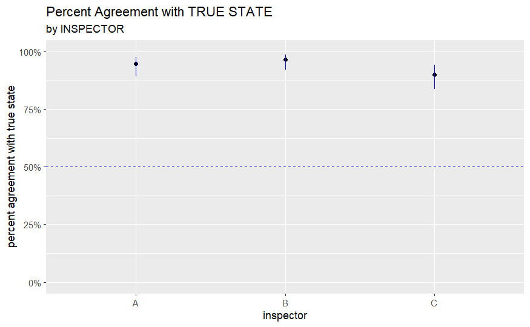

```r
### plot data
d2_summary_byinsp %>%
  # filter(trial_true_agree == 1) %>%
  ggplot(aes(x = inspector, y = estimate)) +
  geom_point() +
  geom_hline(yintercept = 0.5, linetype = 2, color = 'blue') +
  geom_segment(aes(x = inspector, xend = inspector, y = conf.low, yend = conf.high, color = cross50)) +
  ggtitle(label = "Percent Agreement with TRUE STATE",
          subtitle = "by INSPECTOR") +
  scale_y_continuous(labels = scales::percent, limits = c(0, 1)) +
  scale_color_manual(values=c("blue", "red", "#00B81F", "red")) +
  ylab("percent agreement with true state") +
  theme(legend.position = 'none') +
  NULL
```

## agreement with standard - by inspector and standard

```r
d2_summary_byinsp2 <- d2 %>%
  group_by(inspector, true_state) %>%
  summarize(ct_agree = sum(trial_true_agree),
            total_obs = length(trial_true_agree),
            true_state = true_state[1]) %>%
  mutate(prop_correct = map2(ct_agree, total_obs, ~ prop.test(.x, .y, conf.level = 0.95) %>%
                               broom::tidy())) %>%
  unnest(prop_correct) %>%
  mutate(cross50 = case_when(conf.low <= 0.5 ~ 'below',
                             TRUE ~ 'above'))

pander(d2_summary_byinsp2)
```

```
----------------------------------------------------------------------
 inspector   true_state   ct_agree   total_obs   estimate   statistic
----------- ------------ ---------- ----------- ---------- -----------
     A           0           45         48        0.9375      35.02

     A           1           97         102       0.951       81.19

     B           0           45         48        0.9375      35.02

     B           1          100         102       0.9804      92.25

     C           0           42         48        0.875       25.52

     C           1           93         102       0.9118      67.54
----------------------------------------------------------------------

Table: Table continues below


-------------------------------------------------------------------------------
  p.value    parameter   conf.low   conf.high               method
----------- ----------- ---------- ----------- --------------------------------
 3.262e-09       1        0.8179     0.9837     1-sample proportions test with
                                                    continuity correction

 2.054e-19       1        0.8839     0.9818     1-sample proportions test with
                                                    continuity correction

 3.262e-09       1        0.8179     0.9837     1-sample proportions test with
                                                    continuity correction

 7.658e-22       1        0.9241     0.9966     1-sample proportions test with
                                                    continuity correction

 4.376e-07       1        0.7406     0.9481     1-sample proportions test with
                                                    continuity correction

 2.065e-16       1        0.8348     0.9563     1-sample proportions test with
                                                    continuity correction
-------------------------------------------------------------------------------

Table: Table continues below


-----------------------
 alternative   cross50
------------- ---------
  two.sided     above

  two.sided     above

  two.sided     above

  two.sided     above

  two.sided     above

  two.sided     above
-----------------------
```

```r
# d2_summary_byinsp2

# glimpse(d2_summary_byinsp2)
```

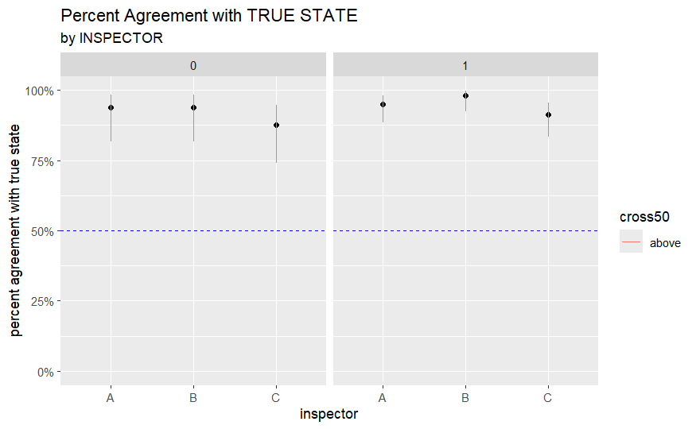

```r
### prep data for plotting
# glimpse(d2_summary_byinsp2)
### plot data
d2_summary_byinsp2 %>%
  # filter(trial_true_agree == 1) %>%
  ggplot(aes(x = inspector, y = estimate)) +
  geom_point() +
  geom_hline(yintercept = 0.5, linetype = 2, color = 'blue') +
  geom_segment(aes(x = inspector, xend = inspector, y = conf.low, yend = conf.high, color = cross50)) +
  ggtitle(label = "Percent Agreement with TRUE STATE",
          subtitle = "by INSPECTOR") +
  scale_y_continuous(labels = scales::percent, limits = c(0, 1)) +
  # scale_color_manual(values=c("blue", "red", "#00B81F", "red")) +
  ylab("percent agreement with true state") +
  # geom_point(aes(x = inspector, y = 0)) +
  # theme(legend.position='none') +
  facet_wrap(~ true_state) +
  NULL
```

## agreement with standard - by specimen (part)

https://stackoverflow.com/questions/50977337/calling-prop-test-function-in-r-with-dplyr

```r
### prep data for plotting -----
d2_summary_bypart <- d2 %>%
  group_by(specimen) %>%
  summarize(ct_agree = sum(trial_true_agree),
            total_obs = length(trial_true_agree),
            true_state = true_state[1]) %>%
  mutate(prop_correct = map2(ct_agree, total_obs, ~ prop.test(.x, .y, conf.level = 0.95) %>%
                               broom::tidy())) %>%
  unnest(prop_correct) %>%
  mutate(cross50 = case_when(conf.low <= 0.5 ~ 'below',
                             TRUE ~ 'above'))

pander(d2_summary_bypart)
```

```
--------------------------------------------------------------------------------
 specimen   ct_agree   total_obs   true_state   estimate   statistic   p.value
---------- ---------- ----------- ------------ ---------- ----------- ----------
   p_01        9           9           1           1         7.111     0.007661

   p_02        9           9           1           1         7.111     0.007661

   p_03        9           9           0           1         7.111     0.007661

   p_04        9           9           0           1         7.111     0.007661

   p_05        9           9           0           1         7.111     0.007661

   p_06        5           9           1         0.5556        0          1

   p_07        8           9           1         0.8889        4        0.0455

   p_08        9           9           1           1         7.111     0.007661

   p_09        9           9           0           1         7.111     0.007661

   p_10        9           9           1           1         7.111     0.007661

   p_11        9           9           1           1         7.111     0.007661

   p_12        8           9           0         0.8889        4        0.0455

   p_13        9           9           1           1         7.111     0.007661

   p_14        6           9           1         0.6667     0.4444      0.505

   p_15        9           9           1           1         7.111     0.007661

   p_16        9           9           1           1         7.111     0.007661

   p_17        9           9           1           1         7.111     0.007661

   p_18        9           9           1           1         7.111     0.007661

   p_19        9           9           1           1         7.111     0.007661
```

[output cut: 312 more lines]

```

  two.sided     above

  two.sided     above

  two.sided     above

  two.sided     above

  two.sided     above

  two.sided     above

  two.sided     above
-----------------------
```

```r
#d2_summary_bypart
#glimpse(d2_summary_bypart)
```

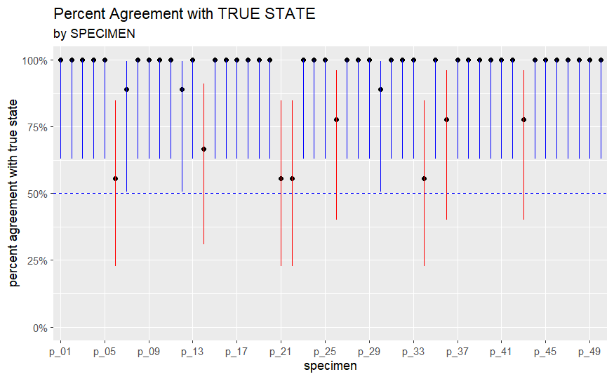

```r
# plot data
d2_summary_bypart %>%
  ggplot(aes(x = specimen, y = estimate)) +
  geom_point() +
  geom_hline(yintercept = 0.5, linetype = 2, color = 'blue') +
  geom_segment(aes(x = specimen, xend = specimen, y = conf.low, yend = conf.high, color = cross50)) +
  ggtitle(label = "Percent Agreement with TRUE STATE",
          subtitle = "by SPECIMEN") +
  scale_y_continuous(labels = scales::percent, limits = c(0, 1)) +
  scale_color_manual(values=c("blue", "red", "#00B81F", "red")) +
  ylab("percent agreement with true state") +
  #geom_point(aes(x = specimen, y = 0, color = true_state), alpha = 0.5) +
  theme(legend.position='none') +
  scale_x_discrete(breaks = function(x) x[seq(1, length(x), by = 4)]) +
  NULL
```

## agreement with standard - by true_state

```r
# prep data for plotting
d2_summary_bystate <- d2 %>%
  group_by(true_state) %>%
  summarize(ct_agree = sum(trial_true_agree),
            total_obs = length(trial_true_agree),
            true_state = true_state[1]) %>%
  mutate(prop_correct = map2(ct_agree, total_obs, ~ prop.test(.x, .y, conf.level = 0.95) %>%
                               broom::tidy())) %>%
  unnest(prop_correct) %>%
  mutate(cross50 = case_when(conf.low <= 0.5 ~ 'below',
                             TRUE ~ 'above')) %>%
  mutate(true_state_char = as.character(true_state))

pander(d2_summary_bystate)
```

```
----------------------------------------------------------------------
 true_state   ct_agree   total_obs   estimate   statistic    p.value
------------ ---------- ----------- ---------- ----------- -----------
     0          132         144       0.9167      98.34     3.523e-23

     1          290         306       0.9477      243.6     6.588e-55
----------------------------------------------------------------------

Table: Table continues below


-------------------------------------------------------------------
 parameter   conf.low   conf.high               method
----------- ---------- ----------- --------------------------------
     1        0.8558     0.9543     1-sample proportions test with
                                        continuity correction

     1        0.9148     0.9688     1-sample proportions test with
                                        continuity correction
-------------------------------------------------------------------

Table: Table continues below


-----------------------------------------
 alternative   cross50   true_state_char
------------- --------- -----------------
  two.sided     above           0

  two.sided     above           1
-----------------------------------------
```

```r
# d2_summary_bystate
# glimpse(d2_summary_bystate)
```

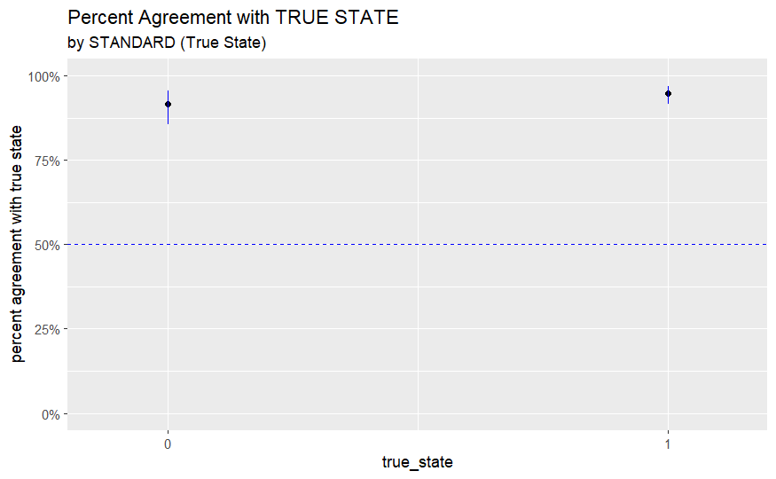

```r
# plot data
d2_summary_bystate %>%
  ggplot(aes(x = true_state, y = estimate)) +
  geom_point() +
  geom_hline(yintercept = 0.5, linetype = 2, color = 'blue') +
  geom_segment(aes(x = true_state, xend = true_state, y = conf.low, yend = conf.high, color = cross50)) +
  ggtitle(label = "Percent Agreement with TRUE STATE",
          subtitle = "by STANDARD (True State)") +
  scale_y_continuous(labels = scales::percent, limits = c(0, 1)) +
  scale_color_manual(values=c("blue", "red", "#00B81F", "red")) +
  ylab("percent agreement with true state") +
  #geom_point(aes(x = true_state, y = 0), alpha = 0.5) +
  theme(legend.position='none') +
  scale_x_continuous(breaks = c(0, 1), expand = 0.1) +
  NULL
```

## agreement with standard - by trial

https://stackoverflow.com/questions/50977337/calling-prop-test-function-in-r-with-dplyr

```r
# prep data for plotting
d2_summary_bytrial <- d2 %>%
  group_by(trial, true_state) %>%
  summarize(ct_agree = sum(trial_true_agree),
            total_obs = length(trial_true_agree),
            true_state = true_state[1]) %>%
  mutate(prop_correct = map2(ct_agree, total_obs, ~ prop.test(.x, .y, conf.level = 0.95) %>%
                               broom::tidy())) %>%
  unnest(prop_correct) %>%
  mutate(cross50 = case_when(conf.low <= 0.5 ~ 'below',
                             TRUE ~ 'above'))

pander(d2_summary_bytrial)
```

```
------------------------------------------------------------------------------
 trial   true_state   ct_agree   total_obs   estimate   statistic    p.value
------- ------------ ---------- ----------- ---------- ----------- -----------
  T1         0           47         48        0.9792      42.19     8.293e-11

  T1         1          101         102       0.9902      96.09     1.099e-22

  T2         0           43         48        0.8958      28.52     9.27e-08

  T2         1           96         102       0.9412      77.66     1.226e-18

  T3         0           42         48        0.875       25.52     4.376e-07

  T3         1           93         102       0.9118      67.54     2.065e-16
------------------------------------------------------------------------------

Table: Table continues below


-------------------------------------------------------------------
 parameter   conf.low   conf.high               method
----------- ---------- ----------- --------------------------------
     1        0.8753     0.9989     1-sample proportions test with
                                        continuity correction

     1        0.9388     0.9995     1-sample proportions test with
                                        continuity correction

     1        0.7656      0.961     1-sample proportions test with
                                        continuity correction

     1        0.8713     0.9759     1-sample proportions test with
                                        continuity correction

     1        0.7406     0.9481     1-sample proportions test with
                                        continuity correction

     1        0.8348     0.9563     1-sample proportions test with
                                        continuity correction
-------------------------------------------------------------------

Table: Table continues below


-----------------------
 alternative   cross50
------------- ---------
  two.sided     above

  two.sided     above

  two.sided     above

  two.sided     above

  two.sided     above

  two.sided     above
-----------------------
```

```r
# d2_summary_bytrial
# glimpse(d2_summary_bytrial)
```

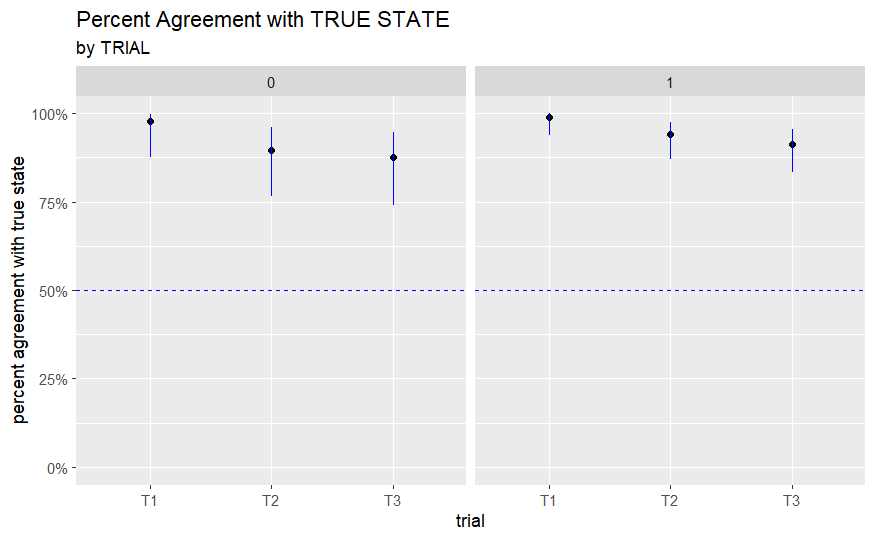

```r
# plot data
d2_summary_bytrial %>%
  ggplot(aes(x = trial, y = estimate)) +
  geom_point() +
  geom_hline(yintercept = 0.5, linetype = 2, color = 'blue') +
  geom_segment(aes(x = trial, xend = trial, y = conf.low, yend = conf.high, color = cross50)) +
  ggtitle(label = "Percent Agreement with TRUE STATE",
          subtitle = "by TRIAL") +
  scale_y_continuous(labels = scales::percent, limits = c(0, 1)) +
  scale_color_manual(values=c("blue", "red", "#00B81F", "red")) +
  ylab("percent agreement with true state") +
  theme(legend.position='none') +
  facet_wrap(~ true_state) +
  NULL
```